# Paired Samples t-Test

ChatGPT 4o

2025-01-21

配对样本t检验（Paired Samples T-Test）是一种统计方法，用于比较两个相关样本（或配对数据）之间的平均值差异。它最初由威廉·戈塞特（William Gosset）在酿酒业中开发，以检查配对数据之间的变化，例如实验前后同一对象的测量值。配对样本t检验随着时间的推移被广泛应用于不同的科学领域，例如医学、心理学和教育学。

## 1 原理

配对样本t检验（Paired Samples T-Test）是一种统计方法，用于比较两个相关样本（或配对数据）之间的平均值差异。它通常用于处理同一个群体的两个不同条件下的数据，或相同对象在不同时间点的测量结果。通过计算两组数据的差值，并进行t统计量检验，可以判断这两组均值是否存在显著差异。

假设检验中，原假设（$H_0$）为两组均值无显著差异，即均值差为零；备择假设（$H_1$）为两组均值存在显著差异。配对样本t检验适用于数据服从正态分布的情况，通过计算均值差、标准差和标准误差，最终求得t值，并与t分布表中的临界值对比，确定是否拒绝原假设。

公式如下：

$$t = \frac{\bar{d}}{s_d/\sqrt{n}}$$

其中，$\bar{d}$ 表示差值的均值，$s_d$ 表示差值的标准差，$n$ 表示样本对的数量。

## 2 适用范围

配对样本t检验适用于以下情况：

- 两组数据之间存在配对关系，即两组数据来自相同个体或相关个体。
- 关注两组数据的平均值是否存在显著差异。
- 数据呈连续型，且两组数据的差值满足正态分布。
- 例如，前后测量同一组对象的体重变化、治疗前后病人的症状改善情况等。

## 3 应用情境

配对样本t检验在许多实际应用中都非常有用，尤其是在涉及重复测量和配对实验的场景中。例如：

- **医学研究**：对病人进行治疗前后的一项生理指标（如血压）进行比较，验证某种药物是否有效。
- **教育实验**：对学生进行某种教学干预前后的考试成绩进行比较，以判断该干预的有效性。
- **心理学实验**：对受试者进行某种刺激前后的反应时间进行比较，评估刺激是否对受试者有显著影响。

## 4 优缺点

### 优点

- **减少个体差异的影响**：由于配对样本来自同一个体或高度相关的个体，配对样本t检验可以有效减少个体间差异对结果的影响，提高检验的统计效能。
- **数据需求较少**：配对样本t检验比独立样本t检验的数据需求较少，因为同一组个体在不同条件下的数据可以进行配对对比。

### 缺点

- **对正态性要求较高**：配对样本t检验要求数据的差值服从正态分布，如果差值不满足正态性，结果的可靠性可能受到影响。
- **不适合独立样本**：该检验仅适用于配对样本，若样本独立，使用配对t检验会导致错误结论。

## 5 在R中的实现及结果解释

在R中，配对样本t检验可以通过`t.test()`函数实现。以下是一个实现示例：

```r
# 示例数据：某实验前后测量的体重数据（单位：kg）
before <- c(70, 68, 75, 80, 72, 78, 74)
after <- c(68, 67, 73, 78, 71, 76, 73)

# 进行配对样本t检验
test_result <- t.test(before, after, paired = TRUE)
# 输出结果
print(test_result)
```

```
##
##  Paired t-test
##
## data:  before and after
## t = 7.7782, df = 6, p-value = 0.0002377
## alternative hypothesis: true mean difference is not equal to 0
## 95 percent confidence interval:
##  1.077078 2.065779
## sample estimates:
## mean difference
##        1.571429
```

```r
summary(test_result)
```

```
##             Length Class  Mode
## statistic   1      -none- numeric
## parameter   1      -none- numeric
## p.value     1      -none- numeric
## conf.int    2      -none- numeric
## estimate    1      -none- numeric
## null.value  1      -none- numeric
## stderr      1      -none- numeric
## alternative 1      -none- character
## method      1      -none- character
## data.name   1      -none- character
```

```r
str(test_result)
```

```
## List of 10
##  $ statistic  : Named num 7.78
##   ..- attr(*, "names")= chr "t"
##  $ parameter  : Named num 6
##   ..- attr(*, "names")= chr "df"
##  $ p.value    : num 0.000238
##  $ conf.int   : num [1:2] 1.08 2.07
##   ..- attr(*, "conf.level")= num 0.95
##  $ estimate   : Named num 1.57
##   ..- attr(*, "names")= chr "mean difference"
##  $ null.value : Named num 0
##   ..- attr(*, "names")= chr "mean difference"
##  $ stderr     : num 0.202
##  $ alternative: chr "two.sided"
##  $ method     : chr "Paired t-test"
##  $ data.name  : chr "before and after"
##  - attr(*, "class")= chr "htest"
```

```r
test_result$method
```

```
## [1] "Paired t-test"
```

```r
test_result$null.value
```

```
## mean difference
##               0
```

```r
test_result$alternative
```

```
## [1] "two.sided"
```

```r
test_result$estimate
```

```
## mean difference
##        1.571429
```

```r
test_result$stderr
```

```
## [1] 0.2020305
```

```r
test_result$statistic
```

```
##        t
## 7.778175
```

```r
test_result$parameter
```

```
## df
##  6
```

```r
test_result$p.value
```

```
## [1] 0.0002377444
```

```r
test_result$conf.int
```

```
## [1] 1.077078 2.065779
## attr(,"conf.level")
## [1] 0.95
```

```r
test_result$conf.int[1]
```

```
## [1] 1.077078
```

```r
test_result$conf.int[2]
```

```
## [1] 2.065779
```

### 结果解释

运行上述代码后，将输出配对样本t检验的结果，主要包括以下内容：

- **t值**：表示检验统计量的值。
- **自由度（df）**：计算t值时使用的自由度。
- **p值**：用于判断原假设是否成立。如果p值小于显著性水平（如0.05），则拒绝原假设，说明两组均值之间存在显著差异。
- **均值差的置信区间**：给出均值差的置信区间，用于描述估计的不确定性。
- **t = 7.78**：表示t统计量的值。
- **df = 6**：表示自由度为6。
- **p-value = 0.0002**：p值小于0.05，说明在95%的置信水平下，可以拒绝原假设，表明前后均值存在显著差异。
- **mean of the differences = 1.57**：表示均值差为1.57，表明体重在实验后有所减轻。

### 等价方法

```r
d <-  after - before
d
```

```
## [1] -2 -1 -2 -2 -1 -2 -1
```

```r
d_result <- t.test(d)
summary(d_result)
```

```
##             Length Class  Mode
## statistic   1      -none- numeric
## parameter   1      -none- numeric
## p.value     1      -none- numeric
## conf.int    2      -none- numeric
## estimate    1      -none- numeric
## null.value  1      -none- numeric
## stderr      1      -none- numeric
## alternative 1      -none- character
## method      1      -none- character
## data.name   1      -none- character
```

```r
str(d_result)
```

```
## List of 10
##  $ statistic  : Named num -7.78
##   ..- attr(*, "names")= chr "t"
##  $ parameter  : Named num 6
##   ..- attr(*, "names")= chr "df"
##  $ p.value    : num 0.000238
##  $ conf.int   : num [1:2] -2.07 -1.08
##   ..- attr(*, "conf.level")= num 0.95
##  $ estimate   : Named num -1.57
##   ..- attr(*, "names")= chr "mean of x"
##  $ null.value : Named num 0
##   ..- attr(*, "names")= chr "mean"
##  $ stderr     : num 0.202
##  $ alternative: chr "two.sided"
##  $ method     : chr "One Sample t-test"
##  $ data.name  : chr "d"
##  - attr(*, "class")= chr "htest"
```

```r
d_result$method
```

```
## [1] "One Sample t-test"
```

```r
d_result$null.value
```

```
## mean
##    0
```

```r
d_result$alternative
```

```
## [1] "two.sided"
```

```r
d_result$estimate
```

```
## mean of x
## -1.571429
```

```r
d_result$stderr
```

```
## [1] 0.2020305
```

```r
t.value <- unname(d_result$estimate)/d_result$stderr
print(t.value)
```

```
## [1] -7.778175
```

```r
d_result$statistic
```

```
##         t
## -7.778175
```

```r
d_result$parameter
```

```
## df
##  6
```

```r
d_result$p.value
```

```
## [1] 0.0002377444
```

```r
d_result$conf.int
```

```
## [1] -2.065779 -1.077078
## attr(,"conf.level")
## [1] 0.95
```

```r
d_result$conf.int[1]
```

```
## [1] -2.065779
```

```r
d_result$conf.int[2]
```

```
## [1] -1.077078
```

### 结果的可视化

可以使用R中的`ggplot2`包对结果进行可视化，以更直观地展示前后测量的差异。

```r
# 加载ggplot2包
library(ggplot2)

# 创建数据框
data <- data.frame(
  subject = rep(1:length(before),2),
  Group = rep(c("Before", "After"), each = length(before)),
  Weight = c(before, after)
)
data
```

```
##    subject  Group Weight
## 1        1 Before     70
## 2        2 Before     68
## 3        3 Before     75
## 4        4 Before     80
## 5        5 Before     72
## 6        6 Before     78
## 7        7 Before     74
## 8        1  After     68
## 9        2  After     67
## 10       3  After     73
## 11       4  After     78
## 12       5  After     71
## 13       6  After     76
## 14       7  After     73
```

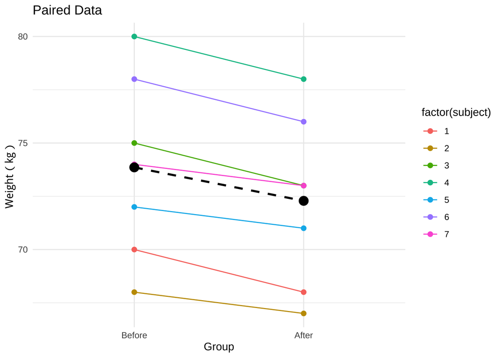

```r
# 绘制线图
ggplot(data, aes(x = Group, y = Weight, group = subject,color = factor(subject))) +
  geom_point(size = 2)+
  geom_line( ) +
  stat_summary(fun = mean, geom = "point", aes(group = 1), size = 4, color = "black") +  # 均值点
  stat_summary(fun = mean, geom = "line", aes(group = 1), linewidth = 1, color = "black", linetype = "dashed") +  # 均值线

  scale_x_discrete(limits = c("Before", "After")) +
  labs(title = "Paired Data", x = "Group", y = "Weight（kg）") +
  theme_minimal()
```

## 6 小结

- 配对样本t检验用于比较同一组个体在两个不同条件下的均值差异。
- 具有减少个体差异影响、数据需求较少的优点。
- 需要满足差值正态性的要求，不适用于独立样本。
- 可以通过R中的`t.test()`函数实现，并结合可视化更直观地展示结果。
- 在医学、教育、心理学等领域有广泛的应用价值。